# R Notebook

**Principles of Data Visualization and Introduction to ggplot2**

I have provided you with data about the 5,000 fastest growing companies in the US, as compiled by Inc. magazine. lets read this in:

```r
inc <- read.csv("https://raw.githubusercontent.com/charleyferrari/CUNY_DATA_608/master/module1/Data/inc5000_data.csv", header= TRUE)
```

And lets preview this data:

```r
head(inc)
```

|  | Rank | Name | Growth_Rate | Revenue | Industry | Employees | City | State |
| --- | --- | --- | --- | --- | --- | --- | --- | --- |
| 1 | 1 | Fuhu | 421.48 | 1.179e+08 | Consumer Products & Services | 104 | El Segundo | CA |
| 2 | 2 | FederalConference.com | 248.31 | 4.960e+07 | Government Services | 51 | Dumfries | VA |
| 3 | 3 | The HCI Group | 245.45 | 2.550e+07 | Health | 132 | Jacksonville | FL |
| 4 | 4 | Bridger | 233.08 | 1.900e+09 | Energy | 50 | Addison | TX |
| 5 | 5 | DataXu | 213.37 | 8.700e+07 | Advertising & Marketing | 220 | Boston | MA |
| 6 | 6 | MileStone Community Builders | 179.38 | 4.570e+07 | Real Estate | 63 | Austin | TX |

```r
NA
```

```r
summary(inc)
```

```
      Rank          Name            Growth_Rate         Revenue            Industry
 Min.   :   1   Length:5001        Min.   :  0.340   Min.   :2.000e+06   Length:5001
 1st Qu.:1252   Class :character   1st Qu.:  0.770   1st Qu.:5.100e+06   Class :character
 Median :2502   Mode  :character   Median :  1.420   Median :1.090e+07   Mode  :character
 Mean   :2502                      Mean   :  4.612   Mean   :4.822e+07
 3rd Qu.:3751                      3rd Qu.:  3.290   3rd Qu.:2.860e+07
 Max.   :5000                      Max.   :421.480   Max.   :1.010e+10

   Employees           City              State
 Min.   :    1.0   Length:5001        Length:5001
 1st Qu.:   25.0   Class :character   Class :character
 Median :   53.0   Mode  :character   Mode  :character
 Mean   :  232.7
 3rd Qu.:  132.0
 Max.   :66803.0
 NA's   :12
```

Think a bit on what these summaries mean. Use the space below to add some more relevant non-visual exploratory information you think helps you understand this data:

```r
dim(inc)
```

```
[1] 5001    8
```

```r
sapply(inc, class)
```

```
       Rank        Name Growth_Rate     Revenue    Industry   Employees        City       State
  "integer" "character"   "numeric"   "numeric" "character"   "integer" "character" "character"
```

```r
str(inc)
```

```
'data.frame':   5001 obs. of  8 variables:
 $ Rank       : int  1 2 3 4 5 6 7 8 9 10 ...
 $ Name       : chr  "Fuhu" "FederalConference.com" "The HCI Group" "Bridger" ...
 $ Growth_Rate: num  421 248 245 233 213 ...
 $ Revenue    : num  1.18e+08 4.96e+07 2.55e+07 1.90e+09 8.70e+07 ...
 $ Industry   : chr  "Consumer Products & Services" "Government Services" "Health" "Energy" ...
 $ Employees  : int  104 51 132 50 220 63 27 75 97 15 ...
 $ City       : chr  "El Segundo" "Dumfries" "Jacksonville" "Addison" ...
 $ State      : chr  "CA" "VA" "FL" "TX" ...
```

## Question 1

Create a graph that shows the distribution of companies in the dataset by State (ie how many are in each state). There are a lot of States, so consider which axis you should use. This visualization is ultimately going to be consumed on a ‘portrait’ oriented screen (ie taller than wide), which should further guide your layout choices.

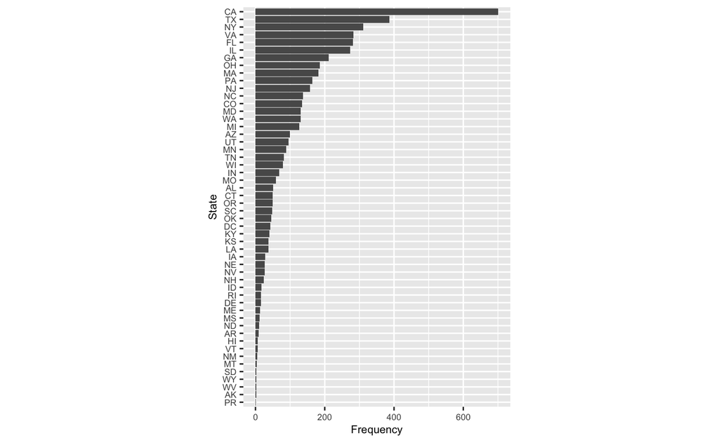

```r
# Answer Question 1 here
library(ggplot2)
q1.tbl <- data.frame(table(inc$State))

ggplot(data=q1.tbl, aes(x=Freq, y=reorder(Var1,Freq))) +
  geom_bar(stat="identity") +
  labs(x="Frequency", y="State") +
  theme(aspect.ratio=1.5,
        text=element_text(size=8))
```

## Quesiton 2

Lets dig in on the state with the 3rd most companies in the data set. Imagine you work for the state and are interested in how many people are employed by companies in different industries. Create a plot that shows the average and/or median employment by industry for companies in this state (only use cases with full data, use R’s `complete.cases()` function.) In addition to this, your graph should show how variable the ranges are, and you should deal with outliers.

```r
# Answer Question 2 here
inc.complt <- inc[complete.cases(inc),]
inc.complt.ny <- inc.complt[inc.complt$State=="NY",]

# Detect outliers
ggplot(data=inc.complt.ny, aes(x=Employees, y=Industry, by=Industry)) +
  geom_boxplot()
```

[output not shown]

```r
# list outlier companies to make note of them.
inc.complt.ny[inc.complt.ny$Employees > 1000,]
```

[output not shown]

```r
# Get rid of 9 outliers with employees over 1000 to highlight the range
table(inc.complt.ny$Employees <= 1000)
```

[output not shown]

```r
inc.complt.ny.mod <- inc.complt.ny[inc.complt.ny$Employees <= 1000, ]

ggplot(data=inc.complt.ny.mod, aes(x=Employees, y=Industry, by=Industry)) +
  geom_boxplot()
```

[output not shown]

## Question 3

Now imagine you work for an investor and want to see which industries generate the most revenue per employee. Create a chart that makes this information clear. Once again, the distribution per industry should be shown.

```r
# Answer Question 3 here

per.inds <- data.frame()
for (i in unique(inc.complt$Industry)) {
  per.inds <- rbind(per.inds,
                    colSums(inc.complt[inc.complt$Industry==i,c("Revenue","Employees")])
                    )

}
per.inds$"Industry" <- unique(inc.complt$Industry)
colnames(per.inds) <- c("Revenue","Employees","Industry")
per.inds$"rev.per.empl" <- per.inds$Revenue / per.inds$Employees

per.inds[order(-per.inds$rev.per.empl),]
```

[output not shown]

```r
ggplot(data=per.inds, aes(x=rev.per.empl, y=reorder(Industry,rev.per.empl))) +
  geom_bar(stat="identity") +
  #geom_text(aes(x=0, y=reorder(Industry,rev.per.empl),
  #              label=paste("$",Revenue," / ",Employees)), color='white', size=2, hjust=0.05) +
  labs(x="Revenue / Employees", y="Industry") +
  theme(aspect.ratio=1.5,
        text=element_text(size=8))
```

[output not shown]